# pyspark_coding

Task 1 - Install Spark, download datasets, create final dataframe. If you get an error regarding tar or wget, it is probably due to the Spark file being removed from the repository. Go to https://downloads.apache.org/spark/ and choose an equivalent version of Spark and Hadoop to download. So if 2.4.7 is not available, download the next version. At the time of this project creation, 2.4.7 exists.

```python
!apt-get install openjdk-8-jdk-headless -qq > /dev/null
!wget -q https://downloads.apache.org/spark/spark-2.4.7/spark-2.4.7-bin-hadoop2.7.tgz
!tar xf spark-2.4.7-bin-hadoop2.7.tgz
!pip install -q findspark
```

```python
import os
os.environ["JAVA_HOME"] = "/usr/lib/jvm/java-8-openjdk-amd64"
os.environ["SPARK_HOME"] = "/content/spark-2.4.7-bin-hadoop2.7"
import findspark
findspark.init()
from google.colab import files
from pyspark.sql import SparkSession, Window
from pyspark.sql.functions import isnan, when, count, col, lit, trim, avg, ceil
from pyspark.sql.types import StringType
import matplotlib.pyplot as plt
import pandas as pd
import seaborn as sns
```

```python
!wget https://s3.amazonaws.com/drivendata/data/7/public/4910797b-ee55-40a7-8668-10efd5c1b960.csv -O features.csv
!wget https://s3.amazonaws.com/drivendata/data/7/public/0bf8bc6e-30d0-4c50-956a-603fc693d966.csv -O labels.csv
```

```
--2020-09-29 08:27:11--  https://s3.amazonaws.com/drivendata/data/7/public/4910797b-ee55-40a7-8668-10efd5c1b960.csv
Resolving s3.amazonaws.com (s3.amazonaws.com)... 52.217.86.206
Connecting to s3.amazonaws.com (s3.amazonaws.com)|52.217.86.206|:443... connected.
HTTP request sent, awaiting response... 200 OK
Length: 20069199 (19M) [text/csv]
Saving to: ‘features.csv’

features.csv        100%[===================>]  19.14M  17.2MB/s    in 1.1s

2020-09-29 08:27:13 (17.2 MB/s) - ‘features.csv’ saved [20069199/20069199]

--2020-09-29 08:27:13--  https://s3.amazonaws.com/drivendata/data/7/public/0bf8bc6e-30d0-4c50-956a-603fc693d966.csv
Resolving s3.amazonaws.com (s3.amazonaws.com)... 52.216.113.221
Connecting to s3.amazonaws.com (s3.amazonaws.com)|52.216.113.221|:443... connected.
HTTP request sent, awaiting response... 200 OK
Length: 1148327 (1.1M) [text/csv]
Saving to: ‘labels.csv’

labels.csv          100%[===================>]   1.09M  2.15MB/s    in 0.5s

2020-09-29 08:27:14 (2.15 MB/s) - ‘labels.csv’ saved [1148327/1148327]
```

```python
!ls
```

```
features.csv  spark-2.4.7-bin-hadoop2.7        spark-2.4.7-bin-hadoop2.7.tgz.2
labels.csv    spark-2.4.7-bin-hadoop2.7.tgz
sample_data   spark-2.4.7-bin-hadoop2.7.tgz.1
```

```python
sc=SparkSession.builder.master("local[*]").getOrCreate()
```

```python
feature=sc.read.csv("features.csv",inferSchema=True,header=True)
label=sc.read.csv("labels.csv",inferSchema=True,header=True)
```

```python
print(feature.count())
print(label.count())
print(feature.columns)
print(label.columns)
```

```
59400
59400
['id', 'amount_tsh', 'date_recorded', 'funder', 'gps_height', 'installer', 'longitude', 'latitude', 'wpt_name', 'num_private', 'basin', 'subvillage', 'region', 'region_code', 'district_code', 'lga', 'ward', 'population', 'public_meeting', 'recorded_by', 'scheme_management', 'scheme_name', 'permit', …
['id', 'status_group']
```

```python
data=feature.join(label,on=("id"))
print(data.count())
print(data.columns)
```

```
59400
['id', 'amount_tsh', 'date_recorded', 'funder', 'gps_height', 'installer', 'longitude', 'latitude', 'wpt_name', 'num_private', 'basin', 'subvillage', 'region', 'region_code', 'district_code', 'lga', 'ward', 'population', 'public_meeting', 'recorded_by', 'scheme_management', 'scheme_name', 'permit', …
```

Task 2 - Change column type, drop duplicated rows, remove whitespacs. If you are disconnected, please run the previous cells by clicking on this cell, going to Runtime, then clicking Run before.

```python
print(data.printSchema())
print(data.show(10))
```

```
root
 |-- id: integer (nullable = true)
 |-- amount_tsh: double (nullable = true)
 |-- date_recorded: timestamp (nullable = true)
 |-- funder: string (nullable = true)
 |-- gps_height: integer (nullable = true)
 |-- installer: string (nullable = true)
 |-- longitude: double (nullable = true)
 |-- latitude: double (nullable = true)
 |-- wpt_name: string (nullable = true)
 |-- num_private: integer (nullable = true)
 |-- basin: string (nullable = true)
 |-- subvillage: string (nullable = true)
 |-- region: string (nullable = true)
 |-- region_code: integer (nullable = true)
 |-- district_code: integer (nullable = true)
 |-- lga: string (nullable = true)
 |-- ward: string (nullable = true)
 |-- population: integer (nullable = true)
 |-- public_meeting: boolean (nullable = true)
 |-- recorded_by: string (nullable = true)
 |-- scheme_management: string (nullable = true)
 |-- scheme_name: string (nullable = true)
 |-- permit: boolean (nullable = true)
 |-- construction_year: integer (nullable = true)
 |-- extraction_type: string (nullable = true)
 |-- extraction_type_group: string (nullable = true)
 |-- extraction_type_class: string (nullable = true)
 |-- management: string (nullable = true)
 |-- management_group: string (nullable = true)
 |-- payment: string (nullable = true)
 |-- payment_type: string (nullable = true)
 |-- water_quality: string (nullable = true)
 |-- quality_group: string (nullable = true)
 |-- quantity: string (nullable = true)
 |-- quantity_group: string (nullable = true)
 |-- source: string (nullable = true)
 |-- source_type: string (nullable = true)
 |-- source_class: string (nullable = true)
 |-- waterpoint_type: string (nullable = true)
 |-- waterpoint_type_group: string (nullable = true)
 |-- status_group: string (nullable = true)

None
+-----+----------+-------------------+-------------------+----------+------------+-----------+------------+--------------------+-----------+--------------------+---------------+---------+-----------+-------------+---------------+----------+----------+--------------+--------------------+-------------…
|   id|amount_tsh|      date_recorded|             funder|gps_height|   installer|  longitude|    latitude|            wpt_name|num_private|               basin|     subvillage|   region|region_code|district_code|            lga|      ward|population|public_meeting|         recorded_by|scheme_manage…
+-----+----------+-------------------+-------------------+----------+------------+-----------+------------+--------------------+-----------+--------------------+---------------+---------+-----------+-------------+---------------+----------+----------+--------------+--------------------+-------------…
|69572|    6000.0|2011-03-14 00:00:00|              Roman|      1390|       Roman|34.93809275| -9.85632177|                none|          0|          Lake Nyasa|       Mnyusi B|   Iringa|         11|            5|         Ludewa|  Mundindi|       109|          true|GeoData Consultan...|             …
| 8776|       0.0|2013-03-06 00:00:00|            Grumeti|      1399|     GRUMETI| 34.6987661| -2.14746569|            Zahanati|          0|       Lake Victoria|        Nyamara|     Mara|         20|            2|      Serengeti|     Natta|       280|          null|GeoData Consultan...|            O…
|34310|      25.0|2013-02-25 00:00:00|       Lottery Club|       686|World vision|37.46066446| -3.82132853|         Kwa Mahundi|          0|             Pangani|        Majengo|  Manyara|         21|            4|      Simanjiro|   Ngorika|       250|          true|GeoData Consultan...|             …
|67743|       0.0|2013-01-28 00:00:00|             Unicef|       263|      UNICEF|38.48616088|-11.15529772|Zahanati Ya Nanyumbu|          0|Ruvuma / Southern...|     Mahakamani|   Mtwara|         90|           63|       Nanyumbu|  Nanyumbu|        58|          true|GeoData Consultan...|             …
|19728|       0.0|2011-07-13 00:00:00|        Action In A|         0|     Artisan|31.13084671| -1.82535885|             Shuleni|          0|       Lake Victoria|     Kyanyamisa|   Kagera|         18|            1|        Karagwe|Nyakasimbi|         0|          true|GeoData Consultan...|             …
| 9944|      20.0|2011-03-13 00:00:00|Mkinga Distric Coun|         0|         DWE| 39.1727956| -4.76558728|              Tajiri|          0|             Pangani|    Moa/Mwereme|    Tanga|          4|            8|         Mkinga|       Moa|         1|          true|GeoData Consultan...|             …
|19816|       0.0|2012-10-01 00:00:00|               Dwsp|         0|        DWSP|33.36240982| -3.76636472|          Kwa Ngomho|          0|            Internal|  Ishinabulandi|Shinyanga|         17|            3|Shinyanga Rural|    Samuye|         0|          true|GeoData Consultan...|             …
|54551|       0.0|2012-10-09 00:00:00|              Rwssp|         0|         DWE|32.62061707| -4.22619802|        Tushirikiane|          0|     Lake Tanganyika|Nyawishi Center|Shinyanga|         17|            3|         Kahama|    Chambo|         0|          true|GeoData Consultan...|             …
|53934|       0.0|2012-11-03 00:00:00|           Wateraid|         0|   Water Aid|32.71110001| -5.14671181|   Kwa Ramadhan Musa|          0|     Lake Tanganyika|     Imalauduki|   Tabora|         14|            6|   Tabora Urban|  Itetemia|         0|          true|GeoData Consultan...|             …
|46144|       0.0|2011-08-03 00:00:00|        Isingiro Ho|         0|     Artisan|30.62699053| -1.25705061|             Kwapeto|          0|       Lake Victoria|       Mkonomre|   Kagera|         18|            1|        Karagwe|    Kaisho|         0|          true|GeoData Consultan...|             …
+-----+----------+-------------------+-------------------+----------+------------+-----------+------------+--------------------+-----------+--------------------+---------------+---------+-----------+-------------+---------------+----------+----------+--------------+--------------------+-------------…
only showing top 10 rows

None
```

```python
data=data.withColumn('region_code',col('region_code').cast(StringType())).withColumn('district_code',col('district_code').cast(StringType()))
```

```python
data.printSchema()
```

```
root
 |-- id: integer (nullable = true)
 |-- amount_tsh: double (nullable = true)
 |-- date_recorded: timestamp (nullable = true)
 |-- funder: string (nullable = true)
 |-- gps_height: integer (nullable = true)
 |-- installer: string (nullable = true)
 |-- longitude: double (nullable = true)
 |-- latitude: double (nullable = true)
 |-- wpt_name: string (nullable = true)
 |-- num_private: integer (nullable = true)
 |-- basin: string (nullable = true)
 |-- subvillage: string (nullable = true)
 |-- region: string (nullable = true)
 |-- region_code: string (nullable = true)
 |-- district_code: string (nullable = true)
 |-- lga: string (nullable = true)
 |-- ward: string (nullable = true)
 |-- population: integer (nullable = true)
 |-- public_meeting: boolean (nullable = true)
 |-- recorded_by: string (nullable = true)
 |-- scheme_management: string (nullable = true)
 |-- scheme_name: string (nullable = true)
 |-- permit: boolean (nullable = true)
 |-- construction_year: integer (nullable = true)
 |-- extraction_type: string (nullable = true)
 |-- extraction_type_group: string (nullable = true)
 |-- extraction_type_class: string (nullable = true)
 |-- management: string (nullable = true)
 |-- management_group: string (nullable = true)
 |-- payment: string (nullable = true)
 |-- payment_type: string (nullable = true)
 |-- water_quality: string (nullable = true)
 |-- quality_group: string (nullable = true)
 |-- quantity: string (nullable = true)
 |-- quantity_group: string (nullable = true)
 |-- source: string (nullable = true)
 |-- source_type: string (nullable = true)
 |-- source_class: string (nullable = true)
 |-- waterpoint_type: string (nullable = true)
 |-- waterpoint_type_group: string (nullable = true)
 |-- status_group: string (nullable = true)
```

```python
#data-data.dropDuplicates(['id'])
data.count()
```

```
59400
```

```python
str_cols=[item[0] for item in data.dtypes if item[1].startswith('string')]
for cols in str_cols:
  data=data.withColumn(cols,trim(data[cols]))
```

Task 3 - Remove columns with null values more than a threshold. If you are disconnected, please run the previous cells by clicking on this cell, going to Runtime, then clicking Run before.

```python
data.select([count(when(isnan(c) |col(c).isNull(),c)).alias(c) for c in data.columns if c not in {'date_recorded','public_meeting','permit'}]).show()
```

```
+---+----------+------+----------+---------+---------+--------+--------+-----------+-----+----------+------+-----------+-------------+---+----+----------+-----------+-----------------+-----------+-----------------+---------------+---------------------+---------------------+----------+---------------…
| id|amount_tsh|funder|gps_height|installer|longitude|latitude|wpt_name|num_private|basin|subvillage|region|region_code|district_code|lga|ward|population|recorded_by|scheme_management|scheme_name|construction_year|extraction_type|extraction_type_group|extraction_type_class|management|management_grou…
+---+----------+------+----------+---------+---------+--------+--------+-----------+-----+----------+------+-----------+-------------+---+----+----------+-----------+-----------------+-----------+-----------------+---------------+---------------------+---------------------+----------+---------------…
|  0|         0|  3635|         0|     3655|        0|       0|       0|          0|    0|       371|     0|          0|            0|  0|   0|         0|          0|             3877|      28166|                0|              0|                    0|                    0|         0|               …
+---+----------+------+----------+---------+---------+--------+--------+-----------+-----+----------+------+-----------+-------------+---+----+----------+-----------+-----------------+-----------+-----------------+---------------+---------------------+---------------------+----------+---------------…
```

```python
agg_row=data.select([(count(when(isnan(c) |col(c).isNull(),c))/data.count()).alias(c) for c in data.columns if c not in {'date_recorded','public_meeting','permit'}]).collect()
```

```python
agg_dict_list=[row.asDict()for row in agg_row]
agg_dict=agg_dict_list[0]
```

```python
col_null=list({i for i in agg_dict if agg_dict[i]>0.4})
print(agg_dict)
print(col_null)
data=data.drop(*col_null)
```

```
{'id': 0.0, 'amount_tsh': 0.0, 'funder': 0.0611952861952862, 'gps_height': 0.0, 'installer': 0.061531986531986535, 'longitude': 0.0, 'latitude': 0.0, 'wpt_name': 0.0, 'num_private': 0.0, 'basin': 0.0, 'subvillage': 0.0062457912457912455, 'region': 0.0, 'region_code': 0.0, 'district_code': 0.0, 'lga'…
['scheme_name']
```

Task 4 - Group, aggregate, create pivot table. If you are disconnected, please run the previous cells by clicking on this cell, going to Runtime, then clicking Run before.

```python
data.groupby('recorded_by').count().show()
```

```
+--------------------+-----+
|         recorded_by|count|
+--------------------+-----+
|GeoData Consultan...|59400|
+--------------------+-----+
```

```python
data.groupby('water_quality').count().orderBy('count',ascending=False).show()
```

```
+------------------+-----+
|     water_quality|count|
+------------------+-----+
|              soft|50818|
|             salty| 4856|
|           unknown| 1876|
|             milky|  804|
|          coloured|  490|
|   salty abandoned|  339|
|          fluoride|  200|
|fluoride abandoned|   17|
+------------------+-----+
```

```python
data=data.drop('recorded_by')
```

```python
data.groupBy('status_group').pivot('region').sum('amount_tsh').show()
```

```
+--------------------+---------+-------------+------+---------+------+--------+-----------+-------+--------+--------+-----+--------+-------+-------+---------+--------+---------+---------+--------+------+--------+
|        status_group|   Arusha|Dar es Salaam|Dodoma|   Iringa|Kagera|  Kigoma|Kilimanjaro|  Lindi| Manyara|    Mara|Mbeya|Morogoro| Mtwara| Mwanza|    Pwani|   Rukwa|   Ruvuma|Shinyanga| Singida|Tabora|   Tanga|
+--------------------+---------+-------------+------+---------+------+--------+-----------+-------+--------+--------+-----+--------+-------+-------+---------+--------+---------+---------+--------+------+--------+
|functional needs ...|  10280.0|          0.0|   0.0| 118400.0|   0.0|270770.0|   129248.0| 3625.0| 71315.0|   900.0|  0.0| 70005.0|36240.0|10000.0|    520.0|292980.0| 125650.0|   2200.0|  6505.0|   0.0|  4310.0|
|          functional|1125485.0|     181175.0|   0.0|5515710.0|   0.0|530725.0|  746942.25|24560.0|312745.0| 96786.0|  0.0|587642.0|52710.0|33550.0|1567765.0|776025.0|1827983.0|  53000.0|863415.0|   0.0|600931.0|
|      non functional|  73330.0|       9374.0|   0.0| 752295.0|   0.0|177510.0|   248454.4|15730.0| 31420.0|116700.0|  0.0|184120.0|14096.0| 4500.0| 160560.0|416830.0| 414669.0|   1000.0| 74510.2|   0.0|123237.0|
+--------------------+---------+-------------+------+---------+------+--------+-----------+-------+--------+--------+-----+--------+-------+-------+---------+--------+---------+---------+--------+------+--------+
```

Task 5 - Convert categories with low frequency to Others, impute missing values. If you are disconnected, please run the previous cells by clicking on this cell, going to Runtime, then clicking Run before.

```python
print(str_cols)
```

```
['funder', 'installer', 'wpt_name', 'basin', 'subvillage', 'region', 'region_code', 'district_code', 'lga', 'ward', 'recorded_by', 'scheme_management', 'scheme_name', 'extraction_type', 'extraction_type_group', 'extraction_type_class', 'management', 'management_group', 'payment', 'payment_type', 'wa…
```

```python
for column in str_cols[:2]:
  print(data.groupBy(column).count().orderBy('count',ascending=False).show())
  values_cat=data.groupBy(column).count().collect()
  lessthan=[x[0] for x in values_cat if x[1]<1000]
  data=data.withColumn(column,when(col(column).isin(lessthan),'others').otherwise(col(column)))
  data.groupBy(column).count().orderBy('count',ascending=False).show()
```

```
+--------------------+-----+
|              funder|count|
+--------------------+-----+
|Government Of Tan...| 9084|
|                null| 3635|
|              Danida| 3114|
|              Hesawa| 2202|
|               Rwssp| 1374|
|          World Bank| 1349|
|                Kkkt| 1287|
|        World Vision| 1246|
|              Unicef| 1057|
|               Tasaf|  877|
|    District Council|  843|
|                 Dhv|  829|
|  Private Individual|  826|
|                Dwsp|  811|
|                   0|  777|
|               Norad|  765|
|     Germany Republi|  610|
|                Tcrs|  602|
|   Ministry Of Water|  590|
|               Water|  583|
+--------------------+-----+
only showing top 20 rows

None
+--------------------+-----+
|              funder|count|
+--------------------+-----+
|              others|35052|
|Government Of Tan...| 9084|
|                null| 3635|
|              Danida| 3114|
|              Hesawa| 2202|
|               Rwssp| 1374|
|          World Bank| 1349|
|                Kkkt| 1287|
|        World Vision| 1246|
|              Unicef| 1057|
```

[output cut: 25 more lines]

```
+------------------+-----+
only showing top 20 rows

None
+----------+-----+
| installer|count|
+----------+-----+
|    others|33202|
|       DWE|17402|
|      null| 3655|
|Government| 1825|
|       RWE| 1206|
|     Commu| 1060|
|    DANIDA| 1050|
+----------+-----+
```

```python
data=data.withColumn('population',when(col('population')<2,lit(None)).otherwise(col('population')))
w=Window.partitionBy(data['district_code'])
data=data.withColumn('population',when(col('population').isNull(),avg(data['population']).over(w)).otherwise(col("population")))
data=data.withColumn('population',ceil(data['population']))
data.groupBy('population').count().orderBy('population').show()
```

```
+----------+-----+
|population|count|
+----------+-----+
|      null|   35|
|         2|    4|
|         3|    4|
|         4|   13|
|         5|   44|
|         6|   19|
|         7|    3|
|         8|   23|
|         9|   11|
|        10|  163|
|        11|    7|
|        12|   43|
|        13|   12|
|        14|   18|
|        15|  193|
|        16|    8|
|        17|    6|
|        18|   18|
|        19|    3|
|        20|  462|
+----------+-----+
only showing top 20 rows
```

Task 6 - Make visualizations. If you are disconnected, please run the previous cells by clicking on this cell, going to Runtime, then clicking Run before.

```python
color_status = {'functional': 'green', 'non functional': 'red', 'functional needs repair': 'blue'}
```

```python
cols=['status_group','payment_type','longitude','latitude','gps_height']
df=data.select(cols).toPandas()
```

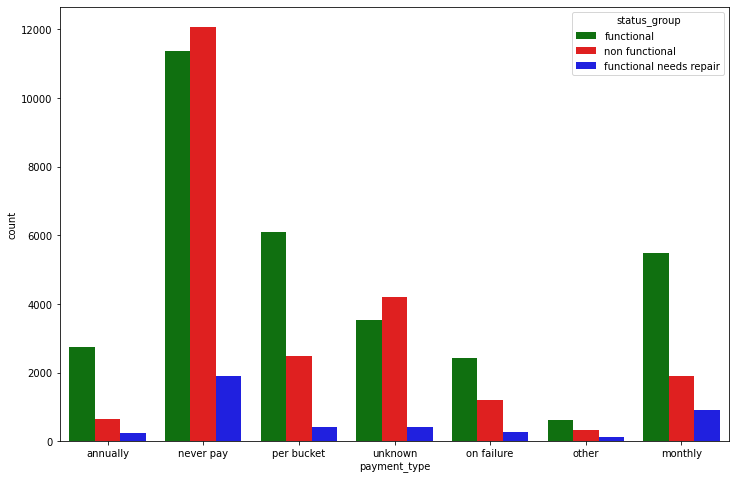

```python
fig,ax=plt.subplots(figsize=(12,8))
sns.countplot(x='payment_type',hue='status_group',data=df,ax=ax,palette=color_status)
```

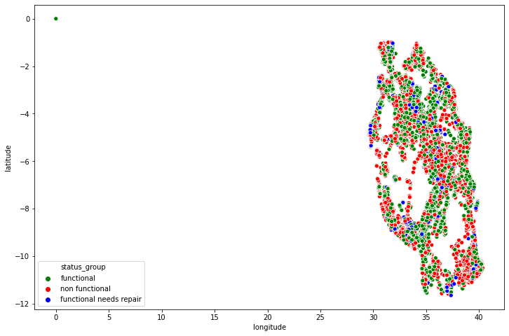

```python
fig,ax=plt.subplots(figsize=(12,8))
sns.scatterplot(x='longitude',y='latitude',hue='status_group',data=df,ax=ax,palette=color_status)
```

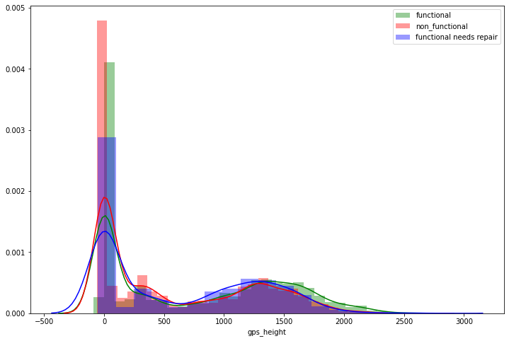

```python
row_functional=(df['status_group']=='functional')
row_non_functional=(df['status_group']=='non functional')
row_repair=(df['status_group']=='functional needs repair')
col='gps_height'
fig,ax=plt.subplots(figsize=(12,8))
sns.distplot(df[col][row_functional],color='green',label='functional',ax=ax)
sns.distplot(df[col][row_non_functional],color='red',label='non_functional',ax=ax)
sns.distplot(df[col][row_repair],color='blue',label='functional needs repair',ax=ax)
plt.legend()
```

```python
data.groupBy(col).count().orderBy(col).show()
```

```
+----------+-----+
|gps_height|count|
+----------+-----+
|       -90|    1|
|       -63|    2|
|       -59|    1|
|       -57|    1|
|       -55|    1|
|       -54|    1|
|       -53|    1|
|       -52|    2|
|       -51|    2|
|       -50|    5|
|       -49|    4|
|       -48|    6|
|       -47|    8|
|       -46|    6|
|       -45|    9|
|       -44|    6|
|       -43|   11|
|       -42|   13|
|       -41|   11|
|       -40|   26|
+----------+-----+
only showing top 20 rows
```